# Seurat tutorial 1 - pbmc3k - with new sctransform steps

## Perform linear dimensional reduction

Seurat provides several useful ways of visualizing both cells and features that define the PCA, including `VizDimReduction()`, `DimPlot()`, and `DimHeatmap()`. In particular `DimHeatmap()` allows for easy exploration of the primary sources of heterogeneity in a dataset, and can be useful when trying to decide which PCs to include for further downstream analyses. Both cells and features are ordered according to their PCA scores. Setting cells to a number plots the ‘extreme’ cells on both ends of the spectrum, which dramatically speeds plotting for large datasets. Though clearly a supervised analysis, we find this to be a valuable tool for exploring correlated feature sets.

### PCA

```r
# perform dimensionality reduction by PCA and UMAP embedding
# These are now standard steps in the Seurat workflow for visualization and clustering
pbmc <- RunPCA(pbmc, verbose = FALSE)

# Examine and visualize PCA results a few different ways
print(pbmc[["pca"]], dims = 1:5, nfeatures = 5)
```

```
PC_ 1
Positive:  FTL, LYZ, FTH1, CST3, S100A9
Negative:  MALAT1, RPS27A, CCL5, LTB, RPS6
PC_ 2
Positive:  HLA-DRA, CD74, CD79A, HLA-DPB1, HLA-DQA1
Negative:  NKG7, CCL5, GZMB, GNLY, GZMA
PC_ 3
Positive:  CD74, HLA-DRA, CD79A, HLA-DPB1, HLA-DQA1
Negative:  S100A8, S100A9, LYZ, RPS12, FTL
PC_ 4
Positive:  FCGR3A, LST1, FCER1G, AIF1, IFITM3
Negative:  S100A8, S100A9, LYZ, LGALS2, CD14
PC_ 5
Positive:  GNLY, GZMB, FGFBP2, FCGR3A, PRF1
Negative:  CCL5, GPX1, PPBP, PF4, SDPR
```

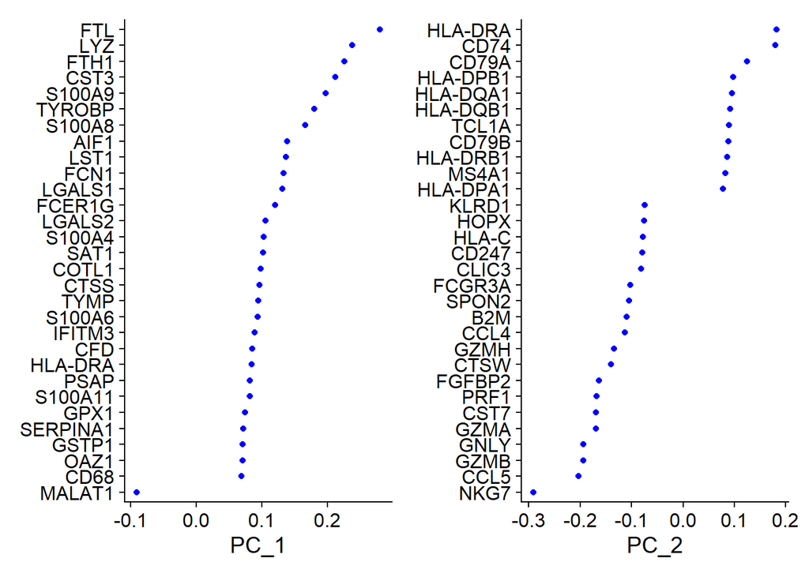

```r
VizDimLoadings(pbmc, dims = 1:2, reduction = "pca")
```

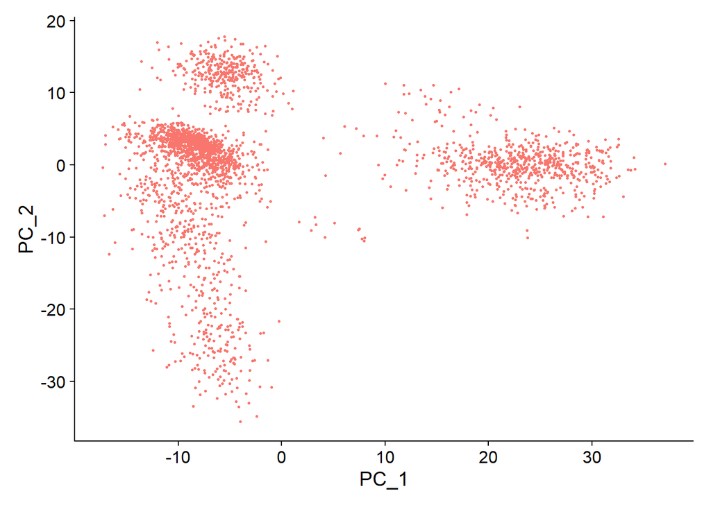

```r
DimPlot(pbmc, reduction = "pca") + NoLegend()
```

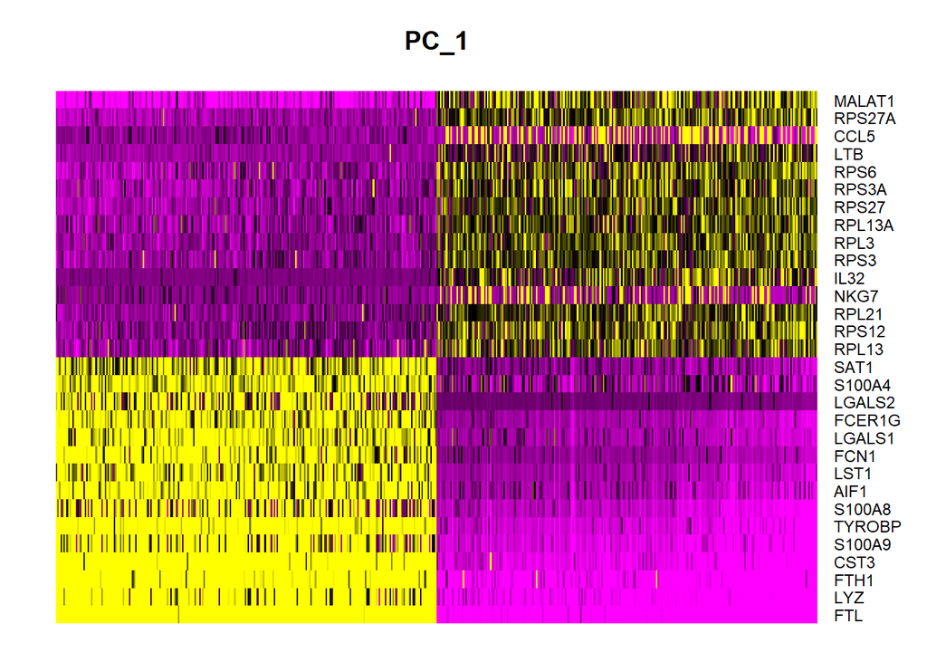

```r
DimHeatmap(pbmc, dims = 1, cells = 500, balanced = TRUE)
```

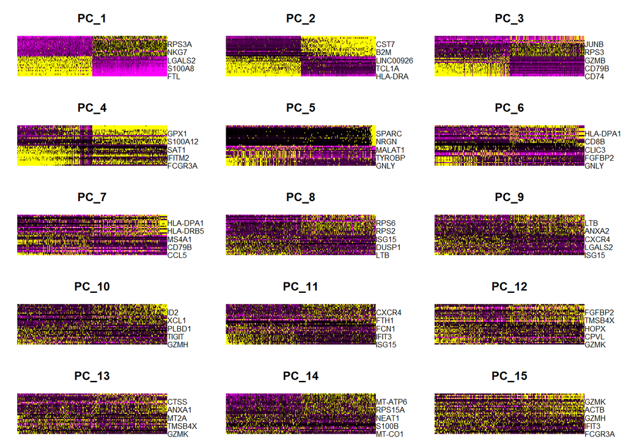

```r
DimHeatmap(pbmc, dims = 1:15, cells = 500, balanced = TRUE)
```

### What is the likely ‘minimal’ dimensionality of the data?

Identifying the true dimensionality of a dataset – can be challenging/uncertain for the user. We therefore suggest these multiple approaches for users. The first is more supervised, exploring PCs to determine relevant sources of heterogeneity, and could be used in conjunction with GSEA for example. The second (`ElbowPlot`) is shown below. The third is a heuristic that is commonly used, and can be calculated instantly. In this example, we might have been justified in choosing anything between PC 7-12 as a cutoff.

- Dendritic cell and NK aficionados may recognize that genes strongly associated with PCs 12 and 13 define rare immune subsets (i.e. MZB1 is a marker for plasmacytoid DCs). However, these groups are so rare, they are difficult to distinguish from background noise for a dataset of this size without prior knowledge.
- We encourage users to repeat downstream analyses with a different number of PCs (10, 15, or even 50!). As you will observe, the results often do not differ dramatically.
- We advise users to err on the higher side when choosing this parameter. For example, performing downstream analyses with only 5 PCs does significantly and adversely affect results.

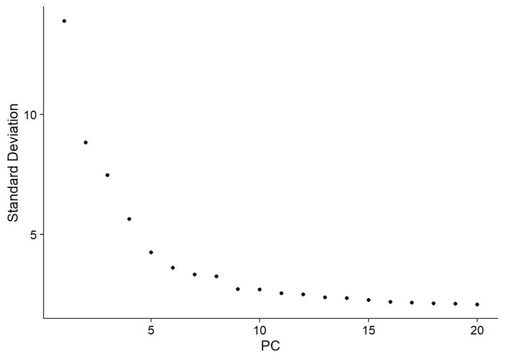

```r
ElbowPlot(pbmc)
```

## Run non-linear dimensional reduction (UMAP)

### UMAP

Seurat offers several non-linear dimensional reduction techniques, such as tSNE and UMAP, to visualize and explore these datasets. The goal of these algorithms is to learn underlying structure in the dataset, in order to place similar cells together in low-dimensional space. Therefore, cells that are grouped together within graph-based clusters determined above should co-localize on these dimension reduction plots.

While we and others have routinely found 2D visualization techniques like tSNE and UMAP to be valuable tools for exploring datasets, all visualization techniques have limitations, and cannot fully represent the complexity of the underlying data. In particular, these methods aim to preserve local distances in the dataset (i.e. ensuring that cells with very similar gene expression profiles co-localize), but often do not preserve more global relationships. We encourage users to leverage techniques like UMAP for visualization, but to avoid drawing biological conclusions solely on the basis of visualization techniques.

### Cluster the cells

Seurat applies a graph-based clustering approach, building upon initial strategies in (Macosko *et al*). Importantly, the *distance metric* which drives the clustering analysis (based on previously identified PCs) remains the same. However, our approach to partitioning the cellular distance matrix into clusters has dramatically improved. Our approach was heavily inspired by recent manuscripts which applied graph-based clustering approaches to scRNA-seq data [[SNN-Cliq, Xu and Su, Bioinformatics, 2015]](http://bioinformatics.oxfordjournals.org/content/early/2015/02/10/bioinformatics.btv088.abstract) and CyTOF data [[PhenoGraph, Levine *et al*., Cell, 2015]](http://www.ncbi.nlm.nih.gov/pubmed/26095251). Briefly, these methods embed cells in a graph structure - for example a K-nearest neighbor (KNN) graph, with edges drawn between cells with similar feature expression patterns, and then attempt to partition this graph into highly interconnected ‘quasi-cliques’ or ‘communities’.

To cluster the cells, we next apply modularity optimization techniques such as the Louvain algorithm (default) or SLM [[SLM, Blondel *et al*., Journal of Statistical Mechanics]](http://dx.doi.org/10.1088/1742-5468/2008/10/P10008), to iteratively group cells together, with the goal of optimizing the standard modularity function. The `FindClusters()` function implements this procedure, and contains a resolution parameter that sets the ‘granularity’ of the downstream clustering, with increased values leading to a greater number of clusters. We find that setting this parameter between 0.4-1.2 typically returns good results for single-cell datasets of around 3K cells. Optimal resolution often increases for larger datasets. The clusters can be found using the `Idents()` function.

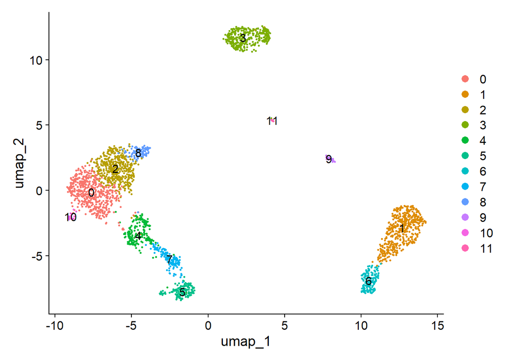

```r
pbmc <- RunUMAP(pbmc, dims = 1:30, verbose = FALSE)
pbmc <- FindNeighbors(pbmc, dims = 1:30, verbose = FALSE)
pbmc <- FindClusters(pbmc, verbose = FALSE)

DimPlot(pbmc, reduction="umap", label = TRUE)
```

### Improvements with sctransform

**Why can we choose more PCs when using sctransform?**

In the standard Seurat workflow we focus on 10 PCs for this dataset, though we highlight that the results are similar with higher settings for this parameter. Interestingly, we’ve found that when using sctransform, we often benefit by pushing this parameter even higher. We believe this is because the sctransform workflow performs more effective normalization, strongly removing technical effects from the data.

Even after standard log-normalization, variation in sequencing depth is still a confounding factor (see [Figure 1](https://genomebiology.biomedcentral.com/articles/10.1186/s13059-019-1874-1)), and this effect can subtly influence higher PCs. In sctransform, this effect is substantially mitigated (see [Figure 3](https://genomebiology.biomedcentral.com/articles/10.1186/s13059-019-1874-1)). This means that higher PCs are more likely to represent subtle, but biologically relevant, sources of heterogeneity – so including them may improve downstream analysis.

In addition, sctransform returns 3,000 variable features by default, instead of 2,000. The rationale is similar, the additional variable features are less likely to be driven by technical differences across cells, and instead may represent more subtle biological fluctuations. In general, we find that results produced with sctransform are less dependent on these parameters (indeed, we achieve nearly identical results when using all genes in the transcriptome, though this does reduce computational efficiency). This can help users generate more robust results, and in addition, enables the application of standard analysis pipelines with identical parameter settings that can quickly be applied to new datasets:

For example, the following code replicates the full end-to-end workflow, in a single command:

```r
pbmc <- CreateSeuratObject(pbmc_data) |>  PercentageFeatureSet(pattern = "^MT-",col.name = 'percent.mt') |>  SCTransform(vars.to.regress = 'percent.mt') |>
  RunPCA() |>  FindNeighbors(dims = 1:30) |>  RunUMAP(dims = 1:30) |> FindClusters()
```

**Where are normalized values stored for sctransform?**

The results of sctransfrom are stored in the “SCT” assay. You can learn more about multi-assay data and commands in Seurat in our vignette, command cheat sheet, or [developer guide](https://github.com/satijalab/seurat/wiki/Assay).

- `pbmc[["SCT"]]$scale.data` contains the residuals (normalized values), and is used directly as input to PCA. Please note that this matrix is non-sparse, and can therefore take up a lot of memory if stored for all genes. To save memory, we store these values only for variable genes, by setting the return.only.var.genes = TRUE by default in the `SCTransform()` function call.
- To assist with visualization and interpretation, we also convert Pearson residuals back to ‘corrected’ UMI counts. You can interpret these as the UMI counts we would expect to observe if all cells were sequenced to the same depth. If you want to see exactly how we do this, please look at the correct function [here](https://github.com/ChristophH/sctransform/blob/master/R/denoise.R).
- The ‘corrected’ UMI counts are stored in `pbmc[["SCT"]]$counts`. We store log-normalized versions of these corrected counts in `pbmc[["SCT"]]$data`, which are very helpful for visualization.

Users can individually annotate clusters based on canonical markers. However, the sctransform normalization reveals sharper biological distinctions compared to the [standard Seurat workflow](https://satijalab.org/seurat/articles/pbmc3k_tutorial), in a few ways:

- Clear separation of at least 3 CD8 T cell populations (naive, memory, effector), based on CD8A, GZMK, CCL5, CCR7 expression
- Clear separation of three CD4 T cell populations (naive, memory, IFN-activated) based on S100A4, CCR7, IL32, and ISG15
- Additional developmental sub-structure in B cell cluster, based on TCL1A, FCER2
- Additional separation of NK cells into CD56dim vs. bright clusters, based on XCL1 and FCGR3A

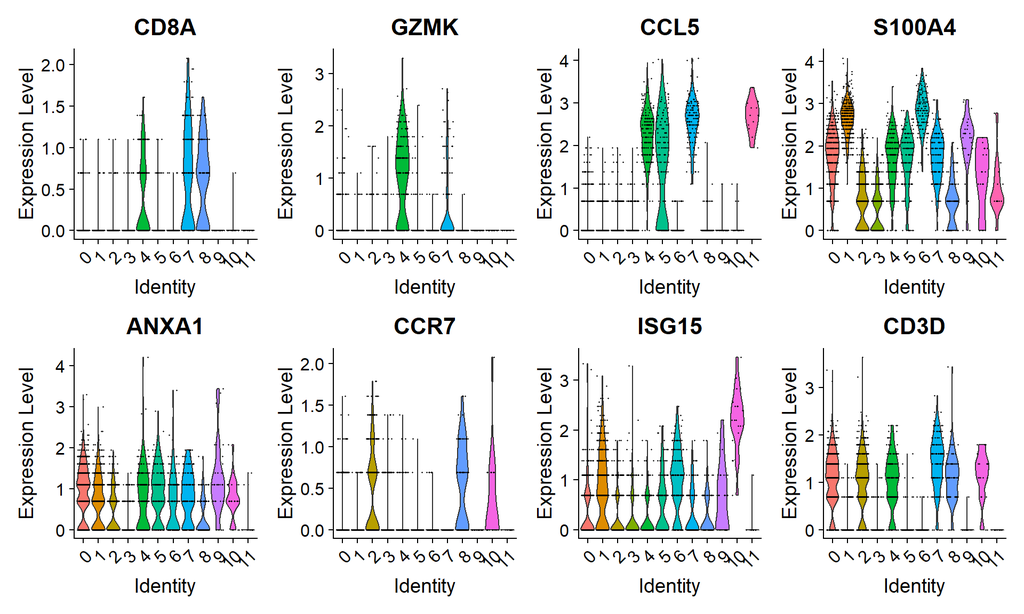

```r
# These are now standard steps in the Seurat workflow for visualization and clustering
# Visualize canonical marker genes as violin plots.
VlnPlot(pbmc, features = c("CD8A", "GZMK", "CCL5", "S100A4", "ANXA1", "CCR7", "ISG15", "CD3D"), pt.size = 0.2, ncol = 4)
```

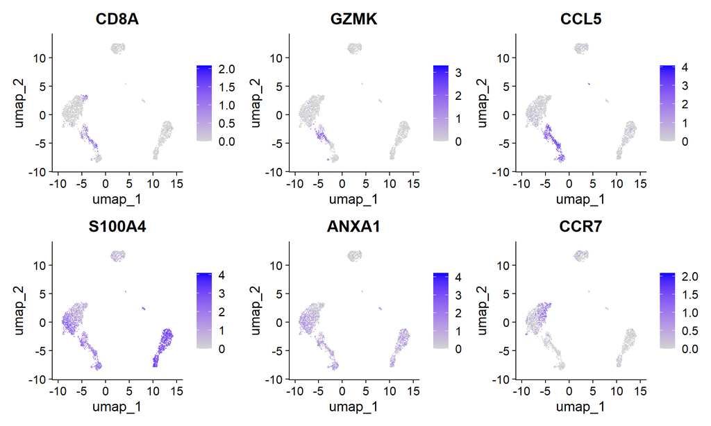

```r
# Visualize canonical marker genes on the sctransform embedding.
FeaturePlot(pbmc, features = c("CD8A", "GZMK", "CCL5", "S100A4", "ANXA1", "CCR7"), pt.size = 0.2, ncol = 3)
```

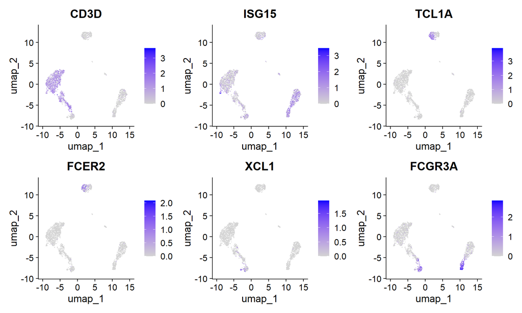

```r
FeaturePlot(pbmc, features = c("CD3D", "ISG15", "TCL1A", "FCER2", "XCL1", "FCGR3A"), pt.size = 0.2, ncol = 3)
```

## Finding differentially expressed features (cluster biomarkers)

Seurat can help you find markers that define clusters via differential expression (DE). By default, it identifies positive and negative markers of a single cluster (specified in `ident.1`), compared to all other cells. `FindAllMarkers()` automates this process for all clusters, but you can also test groups of clusters vs. each other, or against all cells.

In Seurat v5, we use the presto package (as described [here](https://www.biorxiv.org/content/10.1101/653253v1) and available for installation [here](https://github.com/immunogenomics/presto)), to dramatically improve the speed of DE analysis, particularly for large datasets. For users who are not using presto, you can examine the documentation for this function (`?FindMarkers`) to explore the `min.pct` and `logfc.threshold` parameters, which can be increased in order to increase the speed of DE testing.

```r
# find all markers of cluster 2
cluster2.markers <- FindMarkers(pbmc, ident.1 = 2)
head(cluster2.markers, n = 5)
```

```
               p_val avg_log2FC pct.1 pct.2     p_val_adj
RPS27  4.001926e-119  0.7415791 1.000 0.998 5.010012e-115
S100A4 4.926131e-104 -2.4044363 0.641 0.889 6.167024e-100
RPL32  2.990688e-103  0.5955997 1.000 0.999  3.744042e-99
RPS12   1.754227e-98  0.6644546 1.000 1.000  2.196116e-94
RPS6    1.893235e-98  0.6179982 1.000 1.000  2.370141e-94
```

```r
# find all markers distinguishing cluster 5 from clusters 0 and 3
cluster5.markers <- FindMarkers(pbmc, ident.1 = 5, ident.2 = c(0, 3))
head(cluster5.markers, n = 5)
```

```
               p_val avg_log2FC pct.1 pct.2     p_val_adj
GZMB   7.829732e-180   6.719063 0.955 0.030 9.802042e-176
PRF1   1.083811e-156   6.358007 0.936 0.058 1.356822e-152
FGFBP2 1.836385e-151   7.136412 0.846 0.034 2.298970e-147
GNLY   5.214274e-151   7.803776 0.974 0.096 6.527750e-147
GZMA   4.112255e-148   5.330651 0.936 0.069 5.148132e-144
```

```r
# find markers for every cluster compared to all remaining cells, report only the positive ones with at least 2-fold difference
pbmc.markers <- FindAllMarkers(pbmc, only.pos = TRUE)
pbmc.markers |>
    group_by(cluster) |>
    dplyr::filter(avg_log2FC > 1)
```

```
# A tibble: 6,423 × 7
# Groups:   cluster [12]
       p_val avg_log2FC pct.1 pct.2 p_val_adj cluster gene
       <dbl>      <dbl> <dbl> <dbl>     <dbl> <fct>   <chr>
 1 1.25e-114       1.60 0.979 0.634 1.57e-110 0       LTB
 2 4.54e-112       1.46 0.945 0.448 5.68e-108 0       IL32
 3 1.03e- 95       1.64 0.77  0.302 1.29e- 91 0       IL7R
 4 1.91e- 73       3.93 0.227 0.018 2.39e- 69 0       TNFRSF4
 5 1.38e- 72       1.08 0.893 0.422 1.72e- 68 0       CD3D
 6 4.56e- 72       2.44 0.426 0.103 5.71e- 68 0       AQP3
 7 1.42e- 71       1.05 0.932 0.596 1.77e- 67 0       LDHB
 8 3.15e- 59       1.75 0.604 0.239 3.95e- 55 0       CD2
 9 6.54e- 57       2.46 0.297 0.058 8.19e- 53 0       CD40LG
10 6.33e- 52       1.03 0.779 0.399 7.93e- 48 0       CD3E
# ℹ 6,413 more rows
```

Seurat has several tests for differential expression which can be set with the test.use parameter (see our DE vignette for details). For example, the ROC test returns the ‘classification power’ for any individual marker (ranging from 0 - random, to 1 - perfect).

Note the difference in the structure of the `cluster0.markers` object resulting from the ROC test compared to the previous `cluster2.markers` and `cluster5.markers` objects.

```r
cluster0.markers <- FindMarkers(pbmc, ident.1 = 0, logfc.threshold = 0.25, test.use = "roc", only.pos = TRUE)
head(cluster0.markers, n = 5)
```

```
     myAUC  avg_diff power avg_log2FC pct.1 pct.2
LTB  0.818 0.9103478 0.636   1.601374 0.979 0.634
IL32 0.804 0.7212060 0.608   1.457206 0.945 0.448
IL7R 0.759 0.5908513 0.518   1.641836 0.770 0.302
LDHB 0.747 0.4955523 0.494   1.053467 0.932 0.596
CD3D 0.740 0.4702718 0.480   1.076700 0.893 0.422
```

We include several tools for visualizing marker expression. `VlnPlot()` (shows expression probability distributions across clusters), and `FeaturePlot()` (visualizes feature expression on a tSNE or PCA plot) are our most commonly used visualizations. **We also suggest exploring `RidgePlot()`, `CellScatter()`, and `DotPlot()`** as additional methods to view your dataset.

`VlnPlot()`

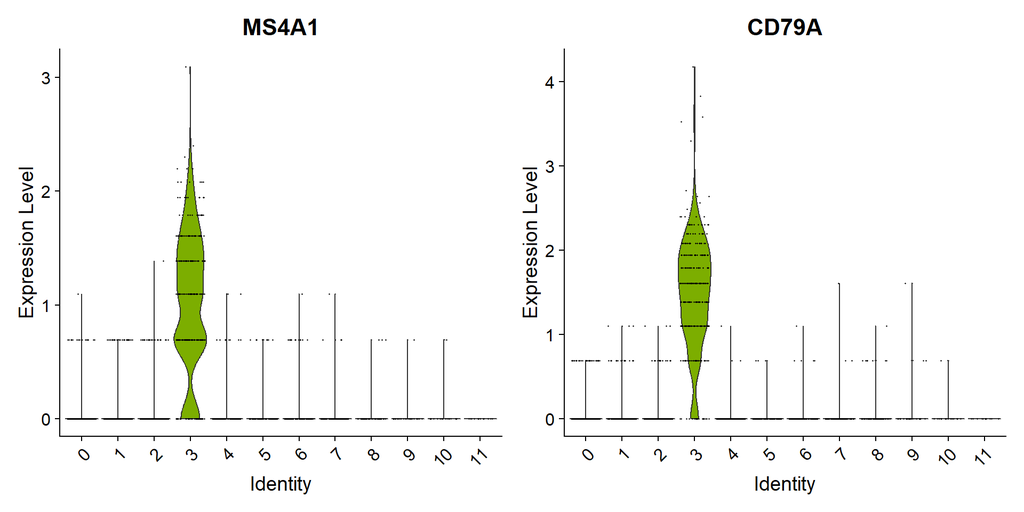

```r
VlnPlot(pbmc, features = c("MS4A1", "CD79A"))
```

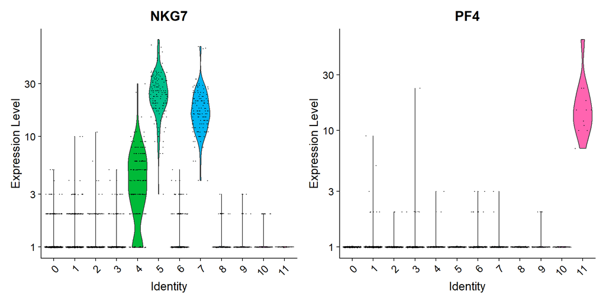

```r
# you can plot raw counts as well
VlnPlot(pbmc, features = c("NKG7", "PF4"), layer = 'counts', log = TRUE)
```

`FeaturePlot()`

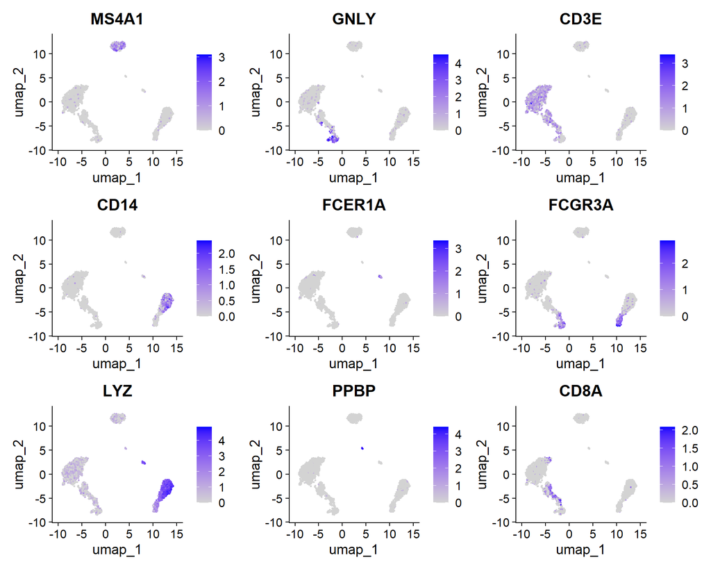

```r
FeaturePlot(pbmc, features = c("MS4A1", "GNLY", "CD3E", "CD14", "FCER1A", "FCGR3A", "LYZ", "PPBP", "CD8A"))
```

`RidgePlot()`

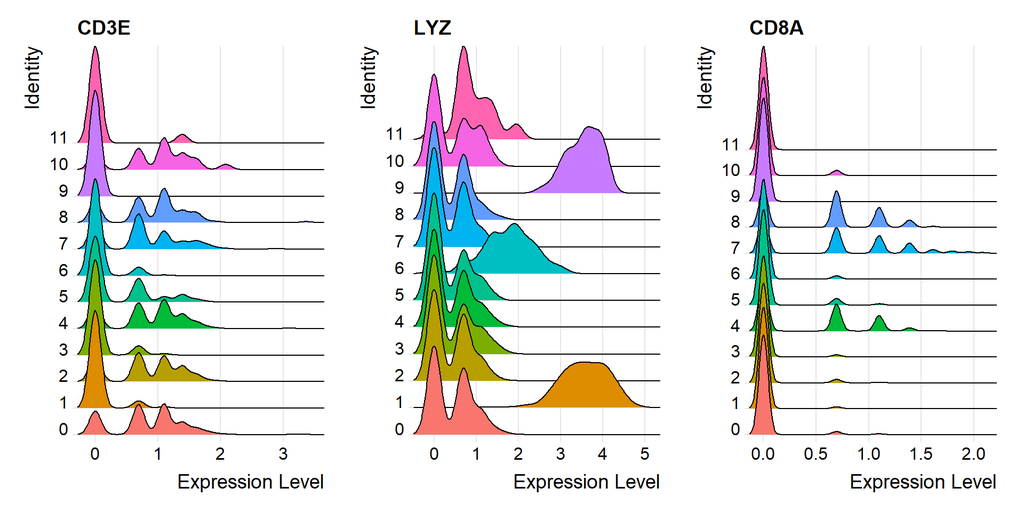

```r
RidgePlot(pbmc, features = c("CD3E", "LYZ", "CD8A"))
```

`CellScatter()` generates a scatter plot of features across two single cells. Pearson correlation between the two cells is displayed above the plot.

`DotPlot()`

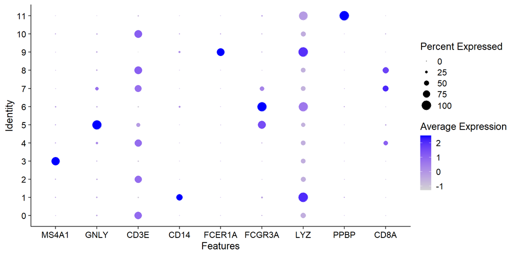

```r
DotPlot(pbmc, features = c("MS4A1", "GNLY", "CD3E", "CD14", "FCER1A", "FCGR3A", "LYZ", "PPBP", "CD8A"))
```

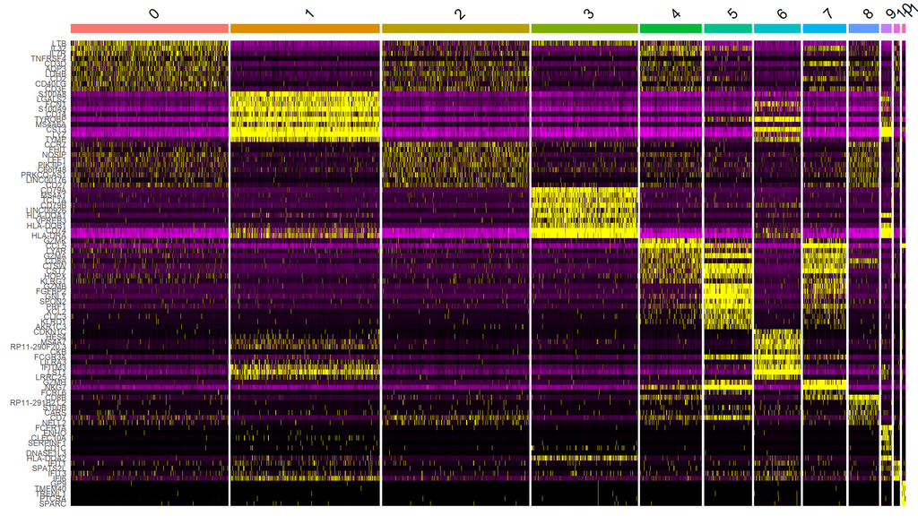

```r
pbmc.markers |>
    group_by(cluster) |>
    dplyr::filter(avg_log2FC > 1) |>
    slice_head(n = 10)|>
    ungroup() -> top10
DoHeatmap(pbmc, features = top10$gene) + NoLegend()
```

### Assigning cell type identity to clusters

Fortunately in the case of this dataset, we can use canonical markers to easily match the unbiased clustering to known cell types. The table below is based on the original pbcm3k guided clustering tutorial, in which 9 clusters were identified. However, in this revised document using `sctransform`, 12 clusters were evident.

Note that the `DoHeatmap` call renders a plot in which the small, additional clusters to the right are very difficult to resolve visually. Inspection of the `top10` tibble derived from `pbmc.markers` was necessary. Remember that `pbmc.markers` contains results from finding markers for every cluster compared to all remaining cells.

Since I am not a PBMC expert I’ve left some of these new clusters labeled as *unknown*.

| Cluster ID | Markers | Cell Type |
| --- | --- | --- |
| 0 | IL7R, CD3E | unknown-1 |
| 1 | CD14, LYZ | CD14+ Mono |
| 2 | CCR7, CD27 | unknown-2 |
| 3 | MS4A1 | B |
| 4 | CD8A | CD8+ T |
| 5 | GNLY, NKG7 | NK |
| 6 | FCGR3A, MS4A7 | FCGR3A+ Mono |
| 7 | CCL5, NKG7 | unknown-3 |
| 8 | CD8A, CD8B | T |
| 9 | FCER1A, ENHO | unknown-4 |
| 10 | IFIT1, IFIT3 | unknown-5 |
| 11 | TREML1, LY6G6F | unknown-6 |

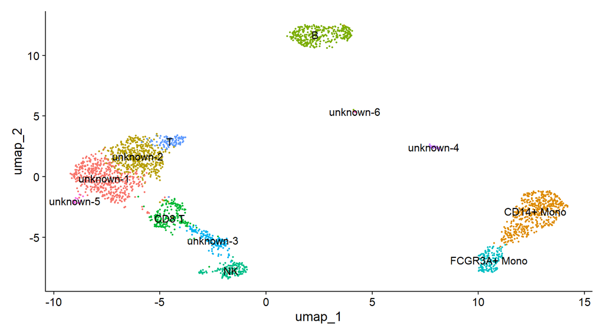

```r
new.cluster.ids <- c("unknown-1", "CD14+ Mono", "unknown-2", "B", "CD8 T", "NK", "FCGR3A+ Mono", "unknown-3", "T", "unknown-4", "unknown-5", "unknown-6")
names(new.cluster.ids) <- levels(pbmc)
pbmc <- RenameIdents(pbmc, new.cluster.ids)
DimPlot(pbmc, reduction = 'umap', label = TRUE, pt.size = 0.5) + NoLegend()
```

The above plot could be modified using `ggplot2` parameters and saved as a graphic file.

```r
library(ggplot2)
plot <- DimPlot(pbmc, reduction = "umap", label = TRUE, label.size = 4.5) + xlab("UMAP 1") + ylab("UMAP 2") +
  theme(axis.title = element_text(size = 18), legend.text = element_text(size = 18)) +
  guides(colour = guide_legend(override.aes = list(size = 10)))
ggsave(filename = file.path(work.dir,"output/pbmc3k_sctransform_umap.jpg"), height = 7, width = 12, plot = plot, quality = 50)
```

All the calculations and modifications performed to the Seurat object could be saved to facilitate future work.

```r
saveRDS(pbmc, file = file.path(work.dir,"output/pbmc3k_sctransform_final.rds"))
```